# Depressive symptoms and associated factors among people living with HIV receiving antiretroviral therapy in Pokhara, Nepal: a cross-sectional study

Khanal R

2026-08-22

# Depressive symptoms and associated factors among people living with HIV receiving antiretroviral therapy in Pokhara, Nepal: a cross-sectional study

## Objectives

#### To determine the prevalence of depression among People Living with HIV (PLHIV) in Kaski District, Nepal.

#### To identify the socio-demographic and behavioral factors associated with depression among PLHIV.

## Methodology:

#### This study used cross-sectional study design done with in an institutional setting at ART centre of Pokhara Academy of Health Science (PAHS). The ART centre at Pokhara Academy of Health Science is largest ART centre in Gandaki province which give regular services to approximately 1000 patient out of 2165 (9). The community-based sampling was not feasible due to lack of baseline on community-level sampling frame of PLHV, therefore institutional based study was performed. This study involved quantitative interview with using socio-demographic questionnaire and a tool for depression assessment. The study population comprised PLHV enrolled at the ART centre who attended the centre for ART services or routine follow-up, the data collection period was between February and March 2019.

#### The eligibility participant were PLHIV aged ≥18 years who provided written informed consent to participate. If a participant did not meet the eligibility criteria, the next eligible client on the ART centre was approached and invited to participate in the study. The research proposal was submitted to the Nepal Health Research Council (NHRC) and received ethical clearence with national ethical guidelines for Health Research in Nepal through Expedited Review Procedure,undersubmission Reg no: 12/2019

```r
# Loading data and packages
library(haven)
library(dplyr)
library(car)
library(forcats)
library(gtsummary)
library(tidyverse)
library(flextable)
library(officer)
library(purrr)
library(ResourceSelection)
```

```
## ResourceSelection 0.3-6   2023-06-27
```

```r
library(pROC)
library(logistf)
#"load the dataset "data2.rds" from your directory"

data1 <- read_rds("data2original.rds") ####
dataset <- data1 %>%
  select(Sex, Age, Residence,Ethinicity,Religion,Marital_status,Family_type,Educational_status,Employment,Occupation,Monthly_income,Family_occupation,Family_income,Family_support,Alcohol_Use,Tobacco_consumption,Cigratte,Surti,Khaini,Gudkha,Drugs_12months,BID_score,Medication_depression,Spouse_support,Involvement_Family,Counseling_depression, Discrimination_Society )

dataset_unique<-dataset
view(dataset_unique)
```

```r
####### Labelling Depression
### Depression 16/17 cut-off (≥17), based on Kohrt BA, Kunz RD, Koirala NR, Sharma VD, Nepal MK. Validation of a Nepali version of the Beck Depression Inventory. Nepalese Journal of Psychiatry. 2002 Jan 1;2(4):123-30.

dataset_unique$Depression_PLWHAS <- cut(
  dataset_unique$BID_score,
  breaks = c(-Inf, 16, Inf),
  labels = c("No Depression", "Depression"),
  right = TRUE
)

summary(dataset_unique$Depression_PLWHAS)
```

```
## No Depression    Depression
##           207            49
```

```r
prop.table(table(dataset_unique$Depression_PLWHAS)) * 100
```

```
##
## No Depression    Depression
##      80.85938      19.14062
```

```r
nrow(dataset_unique)
```

```
## [1] 256
```

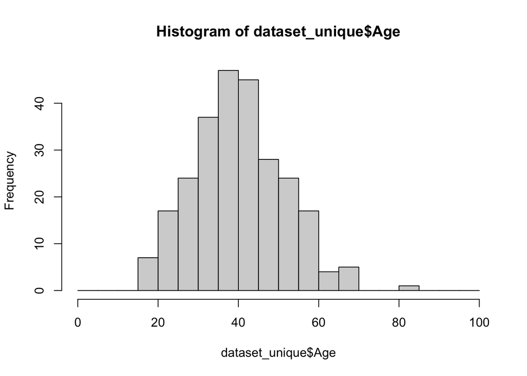

```r
hist(dataset_unique$Age, breaks = seq(0, 100, by = 5))
```

```r
summary(dataset_unique$Monthly_income)
```

```
##    Min. 1st Qu.  Median    Mean 3rd Qu.    Max.    NA's
##    1200   10000   15000   17062   20000  175000      75
```

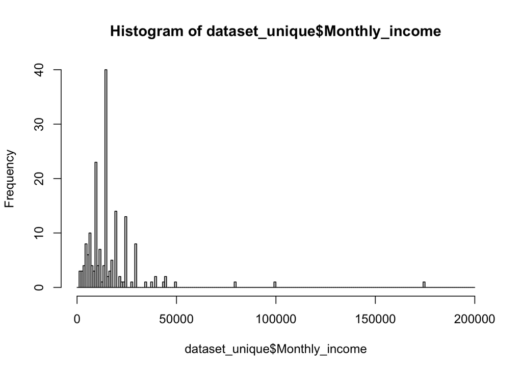

```r
hist(dataset_unique$Monthly_income, breaks = seq(0, 200000, by = 1000))
```

```r
# age is slightly skewed on right because we have participant from 18 yrs and monthly we less adolescent and youth rather than adult population due to decreasing incidence of new case of HIV/AIDS

##  calculating 95% CI

x <- sum(dataset_unique$Depression_PLWHAS == "Depression", na.rm = TRUE)
n <- sum(!is.na(dataset_unique$Depression_PLWHAS))

ci <- prop.test(x, n, correct = FALSE)

prev <- x / n * 100
lower <- ci$conf.int[1] * 100
upper <- ci$conf.int[2] * 100

paste0(
  round(prev, 1), "% (95% CI: ",
  round(lower, 1), "–", round(upper, 1), "%)"
)
```

```
## [1] "19.1% (95% CI: 14.8–24.4%)"
```

```r
###Age in Catagory 49 below and above

dataset_unique <- dataset_unique %>%
  mutate(Age_group = case_when(
    Age < 49 ~ "< 49",
    Age >= 49 ~ "49 ≥",
    TRUE ~ NA_character_
  ))
dataset_unique$Age_group <- factor(dataset_unique$Age_group, levels = c("< 49", "49 ≥"))

####### Sex Male or Female

dataset_unique$Sex <- factor(dataset_unique$Sex,
                             levels = c("1", "2"),
                             labels = c("Male", "Female"))
dataset_unique$Sex <- relevel(dataset_unique$Sex,ref = "Female")

#Male (115), Female (141)

dataset_unique$Residence <- factor(dataset_unique$Residence,
                                   levels = c("1", "2"),
                                   labels = c("Rural", "Urban"))
dataset_unique$Residence <- relevel(
  dataset_unique$Residence,
  ref = "Urban"
)

######### Ethnicity Dalit or Not

dataset_unique$Ethinicity<-as.factor(dataset_unique$Ethinicity)

dataset_unique$Ethnicity <- ifelse(dataset_unique$Ethinicity == 5, "Dalit", "Non-Dalit")
dataset_unique$Ethnicity <- factor(dataset_unique$Ethnicity) #changing the spelling of ethinicity in to ethnicity
dataset_unique$Ethnicity <- relevel(dataset_unique$Ethnicity,ref = "Non-Dalit")

######## Religion

dataset_unique$Religion <- factor(dataset_unique$Religion,
                                  levels = c("1", "2","4","5"),
                                  labels = c("Hindu","Buddhist","Muslim","Christain"))



#######Into 3 catagories
dataset_unique <- dataset_unique %>%
  mutate(
    Marital_3cat = case_when(
      Marital_status == 1 ~ "Unmarried",
      Marital_status == 2 ~ "Married",
      Marital_status %in% c(3, 4, 5) ~ "Divorced/Separated/Widowed",
      TRUE ~ NA_character_
    )
  ) %>%
  mutate(
    # Set "Married" as reference category
    Marital_3cat = factor(
      Marital_3cat,
      levels = c("Married", "Unmarried", "Divorced/Separated/Widowed")
    )
  )
table(dataset_unique$Marital_3cat, useNA = "always")
```

```
##
##                    Married                  Unmarried
##                        165                         29
## Divorced/Separated/Widowed                       <NA>
##                         62                          0
```

```r
######## Family Type
dataset_unique$Family_type <- factor(dataset_unique$Family_type,
                                     levels = c("1", "2"),
                                     labels = c("Joint", "Nuclear"))
dataset_unique$Family_type<-as.factor(dataset_unique$Family_type)

#######Educational Status


dataset_unique$Educational_status <- as.numeric(dataset_unique$Educational_status)
dataset_unique$Educational_status <- case_when(
  dataset_unique$Educational_status == 1 ~ "Illiterate/Informal",
  dataset_unique$Educational_status == 2 ~ "Illiterate/Informal",
  dataset_unique$Educational_status %in% c(3, 4, 5, 6) ~ "Formal Education"
)
dataset_unique$Educational_status<-as.factor(dataset_unique$Educational_status)


#########################################Employment Employed or Unemployed

dataset_unique$Employment <- factor(dataset_unique$Employment,
                                    levels = c("1", "2"),
                                    labels = c("Un-employed", "Employed"))
dataset_unique$Employment<-as.factor(dataset_unique$Employment)

table(dataset_unique$Employment)
```

```
##
## Un-employed    Employed
##          75         181
```

```r
############# Occupation
table(dataset_unique$Occupation)
```

```
##
##  1  4  5  6  7  8
## 52 40 46 17 11 15
```

```r
dataset_unique$Occupation <- factor(dataset_unique$Occupation,
                                       levels = c("1","4","5","6","7","8"),
                                       labels = c("Business","Agriculture", "Labor","Service","Driving","Other"))

dataset_unique$Occupation<-as.factor(dataset_unique$Occupation)

dataset_unique$Occupation2 <- ifelse(
  dataset_unique$Occupation == "Labor",
  "Labor",
  "Non-Labor"
)

dataset_unique$Occupation2 <- factor(
  dataset_unique$Occupation2,
  levels = c("Non-Labor", "Labor")
)


#################################################Family Income


dataset_unique$Family_occupation<-factor(dataset_unique$Family_occupation,
                                       levels = c("1","2","3","4","5","6","7","8"),
                                       labels = c("Business","Agriculture", "Labor","Civil Service","Foreign employment","Pension","Driving","Other"))

dataset_unique$Family_occupation <- as.factor(dataset_unique$Family_occupation)


#### Family_occupation
dataset_unique$Family_occupation2 <- case_when(
  dataset_unique$Family_occupation == "Labor" ~ "Labor",
  !is.na(dataset_unique$Family_occupation) ~ "Non-Labor",
  TRUE ~ NA_character_
)

dataset_unique$Family_occupation2 <- factor(
  dataset_unique$Family_occupation2,
  levels = c("Non-Labor", "Labor")
)

###### Family Income


dataset_unique$Family_income <- factor(dataset_unique$Family_income,
                                       levels = c("1", "2","3"),
                                       labels = c("10K below","10K to 50K", "More than 50K"))
dataset_unique$Family_income<-as.factor(dataset_unique$Family_income)

######### Monthly Income in Percentile

percentiles <- quantile(dataset_unique$Monthly_income,
                        probs = c(0.25, 0.5, 0.75),
                        na.rm = TRUE)

dataset_unique <- dataset_unique %>%
  mutate(Income_percentile_category = case_when(
    is.na(Monthly_income) ~ "No Income",
    Monthly_income <= percentiles[1] ~ "Low Income",
    Monthly_income <= percentiles[2] ~ "Lower-Middle Income",
    Monthly_income <= percentiles[3] ~ "Upper-Middle Income",
    Monthly_income > percentiles[3] ~ "High Income"
  ))

dataset_unique$Income_percentile_category <- factor(
  dataset_unique$Income_percentile_category,
  levels = c(
    "High Income",
    "Upper-Middle Income",
    "Lower-Middle Income",
    "Low Income"
  )
)


#########Alcohol in Use


dataset_unique$Alcohol_Use <- factor(dataset_unique$Alcohol_Use,
                                     levels = c("1", "2"),
                                     labels = c(" Yes ", " No "))
dataset_unique$Alcohol_Use<-as.factor(dataset_unique$Alcohol_Use)

#########Drug in Society


dataset_unique$Drugs_12months <- factor(dataset_unique$Drugs_12months,
                                        levels = c("1", "2"),
                                        labels = c(" Yes ", " No ") )

dataset_unique$Drugs_12months<-as.factor(dataset_unique$Drugs_12months)
dataset_unique$Drugs_12months <- relevel(dataset_unique$Drugs_12months,ref = " No ")

#####

dataset_unique$Tobacco_consumption <- factor(
  dataset_unique$Tobacco_consumption,
  levels = c("1", "2"),
  labels = c(" Yes ", " No ")
)
dataset_unique$Tobacco_consumption<-as.factor(dataset_unique$Tobacco_consumption)

dataset_unique$Tobacco_consumption <- relevel(
  dataset_unique$Tobacco_consumption,
  ref = " No "
)

table(dataset_unique$Tobacco_consumption)
```

```
##
##   No   Yes
##   166    90
```

```r
# [1] "No" "Yes"

#### smoking variable



dataset_unique$Cigratte<-factor(dataset_unique$Cigratte,
                                levels = c("1","2"),
                                labels = c("Yes","No"))

dataset_unique$Khaini<-factor(dataset_unique$Khaini,
                                levels = c("1","2"),
                                labels = c("Yes","No"))
dataset_unique$Surti<-factor(dataset_unique$Surti,
                                levels = c("1","2"),
                                labels = c("Yes","No"))
dataset_unique$Gudkha<-factor(dataset_unique$Gudkha,
                                levels = c("1","2"),
                                labels = c("Yes","No"))

dataset_unique <- dataset_unique %>%
  mutate(
    Smokeless = if_else(
      Khaini == "Yes" |
      Gudkha == "Yes" |
      Surti == "Yes",
      "Yes", "No",
      missing = "No"
    ),

    Tobacco_type = case_when(
      # No tobacco use
      (Cigratte == "No" | is.na(Cigratte)) &
      Smokeless == "No" ~ "No tobacco product",

      # Smoking only
      Cigratte == "Yes" &
      Smokeless == "No" ~ "Smoking only",

      # Smokeless tobacco only
      (Cigratte == "No" | is.na(Cigratte)) &
      Smokeless == "Yes" ~ "Tobacco product",

      # Both cigarette and smokeless
      Cigratte == "Yes" &
      Smokeless == "Yes" ~ "Both",

      TRUE ~ "No tobacco product"
    )
  )

dataset_unique$Tobacco_type <- factor(
  dataset_unique$Tobacco_type,
  levels = c(
    "No tobacco product",
    "Smoking only",
    "Tobacco product",
    "Both"
  )
)

table(dataset_unique$Tobacco_type, useNA = "ifany")
```

```
##
## No tobacco product       Smoking only    Tobacco product               Both
##                167                 37                 45                  7
```

```r
#### Income in catagories


dataset_unique <- dataset_unique %>%
  mutate(
    Income_group = case_when(
      Income_percentile_category == "High Income" ~ "High Income",
      Income_percentile_category %in% c("Upper-Middle Income",
                                        "Lower-Middle Income") ~ "Middle Income",
      Income_percentile_category == "Low Income" ~ "Lower Income",
      is.na(Income_percentile_category) ~ "No income"
    )
  )


dataset_unique <- dataset_unique %>%
  mutate(
    Income_group2 = case_when(
      Income_percentile_category == "High Income" ~ "High",
      Income_percentile_category %in% c("Upper-Middle Income",
                                        "Lower-Middle Income") ~ "High",
      Income_percentile_category == "Low Income" ~ "Low/No",
      is.na(Income_percentile_category) ~ "Low/No"
    )
  )

dataset_unique$Income_group2 <- factor(
  dataset_unique$Income_group2,
  levels = c("High", "Low/No"),
  labels = c(">10000", "≤ 10,000")
)
table(dataset_unique$Income_group2)
```

```
##
##   >10000 ≤ 10,000
##      117      139
```

```r
dataset_unique$Medication_depression <- factor(dataset_unique$Medication_depression,
                                        levels = c("1", "2"),
                                        labels = c(" Yes ", " No "))

dataset_unique$Medication_depression<-as.factor(dataset_unique$Medication_depression)



#########Family Support


dataset_unique$Family_support <- factor(dataset_unique$Family_support,
                                        levels = c("1", "2"),
                                        labels = c(" Yes ", " No "))
dataset_unique$Family_support<-as.factor(dataset_unique$Family_support)



dataset_unique$Family_support<-as.factor(dataset_unique$Family_support)

#########Spouse Support

dataset_unique$Spouse_support<-factor(dataset_unique$Spouse_support,
                                        levels = c("1", "2"),
                                        labels = c(" Yes ", " No "))

dataset_unique$Spouse_support<-as.factor(dataset_unique$Spouse_support)

#### Family involvement

dataset_unique$Involvement_Family<-factor(dataset_unique$Involvement_Family,
                                          levels = c("1", "2"),
                                        labels = c(" Yes ", " No "))
dataset_unique$Involvement_Family<-as.factor(dataset_unique$Involvement_Family)

dataset_unique$Discrimination_Society<-factor(dataset_unique$Discrimination_Society,
                                          levels = c("1", "2"),
                                        labels = c(" Yes ", " No "))

dataset_unique$Discrimination_Society <- relevel(
  dataset_unique$Discrimination_Society,
  ref = " No "
)
```

```r
####
table(data1$Depression_PLWHAS)
```

```
##
##   1   2
##  70 186
```

```r
Depression_Table <- dataset_unique %>%
  select(Depression_PLWHAS,Depression_PLWHAS,BID_score)%>%
  tbl_summary(
    missing = "no"
  ) %>%
  italicize_levels() %>%
  modify_caption("Depression Prevalance")

Depression_Table
```

Depression Prevalance

| **Characteristic** | **N = 256**<sup>1</sup> |
| --- | --- |
| Depression_PLWHAS |  |
| No Depression | 207 (81%) |
| Depression | 49 (19%) |
| Total BID score | 8 (4, 14) |

<sup>1</sup> n (%); Median (Q1, Q3)

```r
summary_flex <- as_flex_table(Depression_Table)

read_docx() %>%
  body_add_flextable(summary_flex) %>%
  print(target = "Depression_Table.docx")
```

```r
####
table(dataset_unique$Occupation2)
```

```
##
## Non-Labor     Labor
##       135        46
```

```r
SocioDemographicTable <- dataset_unique %>%
  select(Sex,Age,Age_group, Residence,Ethnicity,Religion,Marital_3cat,Family_type,
    Educational_status,Employment,Monthly_income,Income_group2,Income_group2,Occupation,
    Family_occupation,Family_income,Family_support,Spouse_support,Discrimination_Society,Tobacco_type,Alcohol_Use,Drugs_12months,Medication_depression )%>%
  tbl_summary(
    missing = "no"
  ) %>%
  italicize_levels() %>%
  modify_caption("Table 1. Socio-demographic Characteristics of Participants")

SocioDemographicTable
```

Table 1. Socio-demographic Characteristics of Participants

| **Characteristic** | **N = 256**<sup>1</sup> |
| --- | --- |
| Sex |  |
| Female | 141 (55%) |
| Male | 115 (45%) |
| Age of the respondent | 40 (34, 49) |
| Age_group |  |
| < 49 | 191 (75%) |
| 49 ≥ | 65 (25%) |
| Residence |  |
| Urban | 216 (84%) |
| Rural | 40 (16%) |
| Ethnicity |  |
| Non-Dalit | 203 (79%) |
| Dalit | 53 (21%) |
| Religion |  |
| Hindu | 197 (77%) |
| Buddhist | 39 (15%) |
| Muslim | 1 (0.4%) |
| Christain | 19 (7.4%) |
| Marital_3cat |  |
| Married | 165 (64%) |
| Unmarried | 29 (11%) |
| Divorced/Separated/Widowed | 62 (24%) |
| Family_type |  |
| Joint | 99 (39%) |
| Nuclear | 157 (61%) |
| Educational_status |  |
| Formal Education | 179 (70%) |
| Illiterate/Informal | 77 (30%) |
| Employment |  |
| Un-employed | 75 (29%) |
| Employed | 181 (71%) |
| Monthly income of the respondent | 15,000 (10,000, 20,000) |
| Income_group2 |  |
| >10000 | 117 (46%) |
| ≤ 10,000 | 139 (54%) |
| Occupation |  |
| Business | 52 (29%) |
| Agriculture | 40 (22%) |
| Labor | 46 (25%) |
| Service | 17 (9.4%) |
| Driving | 11 (6.1%) |
| Other | 15 (8.3%) |
| Family_occupation |  |
| Business | 55 (21%) |
| Agriculture | 52 (20%) |
| Labor | 49 (19%) |
| Civil Service | 21 (8.2%) |
| Foreign employment | 30 (12%) |
| Pension | 16 (6.3%) |
| Driving | 9 (3.5%) |
| Other | 24 (9.4%) |
| Family_income |  |
| 10K below | 24 (9.4%) |
| 10K to 50K | 216 (84%) |
| More than 50K | 16 (6.3%) |
| Family_support |  |
| Yes | 28 (11%) |
| No | 228 (89%) |
| Spouse_support |  |
| Yes | 6 (3.6%) |
| No | 159 (96%) |
| Discrimination_Society |  |
| No | 199 (78%) |
| Yes | 57 (22%) |
| Tobacco_type |  |
| No tobacco product | 167 (65%) |
| Smoking only | 37 (14%) |
| Tobacco product | 45 (18%) |
| Both | 7 (2.7%) |
| Alcohol_Use |  |
| Yes | 57 (22%) |
| No | 199 (78%) |
| Drugs_12months |  |
| No | 246 (96%) |
| Yes | 10 (3.9%) |
| Medication_depression |  |
| Yes | 14 (5.5%) |
| No | 242 (95%) |

<sup>1</sup> n (%); Median (Q1, Q3)

```r
summary_flex <- as_flex_table(SocioDemographicTable)

read_docx() %>%
  body_add_flextable(summary_flex) %>%
  print(target = "SocioDemographic_Characteristics.docx")
```

```r
vars_to_test <- c("Sex", "Age_group","Residence", "Ethnicity", "Marital_3cat",
         "Educational_status", "Employment","Income_group2","Occupation2","Family_occupation2","Family_income"
          ,"Alcohol_Use", "Drugs_12months","Tobacco_consumption","Medication_depression","Family_support","Spouse_support","Involvement_Family","Discrimination_Society")
for (var in vars_to_test) {
  cat("\n=====================================================\n")
  cat("Testing: Depression_PLWHAS vs", var, "\n")

  # Create contingency table
  tbl <- table(dataset_unique$Depression_PLWHAS, dataset_unique[[var]])
# Decide test type based on expected counts
  test_type <- if (any(chisq.test(tbl)$expected < 5)) "Fisher" else "Chi-square"

  if (test_type == "Chi-square") {
    test_result <- chisq.test(tbl)
    cat("Test Used: Chi-square\n")
  } else {
    test_result <- fisher.test(tbl)
    cat("Test Used: Fisher’s Exact Test\n")
  }
  # Print result
  cat("P-value:", round(test_result$p.value, 4), "\n")

  if (test_result$p.value < 0.05) {
    cat("=> Significant association (p < 0.05)\n")
  } else {
    cat("=> Not significant (p >= 0.05)\n")
  }
}
```

```
##
## =====================================================
## Testing: Depression_PLWHAS vs Sex
## Test Used: Chi-square
## P-value: 0.0796
## => Not significant (p >= 0.05)
##
## =====================================================
## Testing: Depression_PLWHAS vs Age_group
## Test Used: Chi-square
## P-value: 1
## => Not significant (p >= 0.05)
##
## =====================================================
## Testing: Depression_PLWHAS vs Residence
## Test Used: Chi-square
## P-value: 0.2134
## => Not significant (p >= 0.05)
##
## =====================================================
## Testing: Depression_PLWHAS vs Ethnicity
## Test Used: Chi-square
## P-value: 0.0039
## => Significant association (p < 0.05)
##
## =====================================================
## Testing: Depression_PLWHAS vs Marital_3cat
## Test Used: Chi-square
## P-value: 0.0011
## => Significant association (p < 0.05)
##
## =====================================================
## Testing: Depression_PLWHAS vs Educational_status
## Test Used: Chi-square
## P-value: 0.1925
## => Not significant (p >= 0.05)
##
## =====================================================
## Testing: Depression_PLWHAS vs Employment
## Test Used: Chi-square
```

[output cut: 8 more lines]

```
##
## =====================================================
## Testing: Depression_PLWHAS vs Occupation2
## Test Used: Chi-square
## P-value: 0.0044
## => Significant association (p < 0.05)
##
## =====================================================
## Testing: Depression_PLWHAS vs Family_occupation2
## Test Used: Chi-square
## P-value: 0.0386
## => Significant association (p < 0.05)
##
## =====================================================
## Testing: Depression_PLWHAS vs Family_income
```

```
## Test Used: Fisher’s Exact Test
## P-value: 0.1864
## => Not significant (p >= 0.05)
##
## =====================================================
## Testing: Depression_PLWHAS vs Alcohol_Use
## Test Used: Chi-square
## P-value: 1
## => Not significant (p >= 0.05)
##
## =====================================================
## Testing: Depression_PLWHAS vs Drugs_12months
```

```
## Test Used: Fisher’s Exact Test
## P-value: 0.102
## => Not significant (p >= 0.05)
##
## =====================================================
## Testing: Depression_PLWHAS vs Tobacco_consumption
## Test Used: Chi-square
## P-value: 6e-04
## => Significant association (p < 0.05)
##
## =====================================================
## Testing: Depression_PLWHAS vs Medication_depression
```

```
## Test Used: Fisher’s Exact Test
## P-value: 1
## => Not significant (p >= 0.05)
##
## =====================================================
## Testing: Depression_PLWHAS vs Family_support
## Test Used: Chi-square
## P-value: 0.9429
## => Not significant (p >= 0.05)
##
## =====================================================
## Testing: Depression_PLWHAS vs Spouse_support
```

```
## Test Used: Fisher’s Exact Test
## P-value: 0.0279
## => Significant association (p < 0.05)
##
## =====================================================
## Testing: Depression_PLWHAS vs Involvement_Family
```

```
## Test Used: Fisher’s Exact Test
## P-value: 0.3523
## => Not significant (p >= 0.05)
##
## =====================================================
## Testing: Depression_PLWHAS vs Discrimination_Society
## Test Used: Chi-square
## P-value: 1e-04
## => Significant association (p < 0.05)
```

```r
Associationtest <- dataset_unique %>%
  select(Sex, Age_group, Residence, Ethnicity, Marital_3cat,
         Educational_status, Employment,Income_group2,Occupation2,Family_income,Family_occupation2, Alcohol_Use,Drugs_12months,Tobacco_consumption,Family_support,Spouse_support,Involvement_Family,Discrimination_Society ,Depression_PLWHAS) %>%
  tbl_summary(
    missing = "no",
    by = Depression_PLWHAS  # Stratify by exposure variable
  ) %>%
  add_p() %>%
  italicize_levels() %>%
  modify_caption("Participant Characteristics by Depression Status")

summary_flex <- as_flex_table(Associationtest)
Associationtest
```

Participant Characteristics by Depression Status

| **Characteristic** | **No Depression** N = 207<sup>1</sup> | **Depression** N = 49<sup>1</sup> | **p-value**<sup>2</sup> |
| --- | --- | --- | --- |
| Sex |  |  | 0.056 |
| Female | 120 (58%) | 21 (43%) |  |
| Male | 87 (42%) | 28 (57%) |  |
| Age_group |  |  | 0.9 |
| < 49 | 154 (74%) | 37 (76%) |  |
| 49 ≥ | 53 (26%) | 12 (24%) |  |
| Residence |  |  | 0.14 |
| Urban | 178 (86%) | 38 (78%) |  |
| Rural | 29 (14%) | 11 (22%) |  |
| Ethnicity |  |  | 0.002 |
| Non-Dalit | 172 (83%) | 31 (63%) |  |
| Dalit | 35 (17%) | 18 (37%) |  |
| Marital_3cat |  |  | 0.001 |
| Married | 144 (70%) | 21 (43%) |  |
| Unmarried | 22 (11%) | 7 (14%) |  |
| Divorced/Separated/Widowed | 41 (20%) | 21 (43%) |  |
| Educational_status |  |  | 0.14 |
| Formal Education | 149 (72%) | 30 (61%) |  |
| Illiterate/Informal | 58 (28%) | 19 (39%) |  |
| Employment |  |  | 0.4 |
| Un-employed | 58 (28%) | 17 (35%) |  |
| Employed | 149 (72%) | 32 (65%) |  |
| Income_group2 |  |  | 0.041 |
| >10000 | 101 (49%) | 16 (33%) |  |
| ≤ 10,000 | 106 (51%) | 33 (67%) |  |
| Occupation2 |  |  | 0.002 |
| Non-Labor | 118 (79%) | 17 (53%) |  |
| Labor | 31 (21%) | 15 (47%) |  |
| Family_income |  |  | 0.2 |
| 10K below | 16 (7.7%) | 8 (16%) |  |
| 10K to 50K | 177 (86%) | 39 (80%) |  |
| More than 50K | 14 (6.8%) | 2 (4.1%) |  |
| Family_occupation2 |  |  | 0.023 |
| Non-Labor | 173 (84%) | 34 (69%) |  |
| Labor | 34 (16%) | 15 (31%) |  |
| Alcohol_Use |  |  | >0.9 |
| Yes | 46 (22%) | 11 (22%) |  |
| No | 161 (78%) | 38 (78%) |  |
| Drugs_12months |  |  | 0.10 |
| No | 201 (97%) | 45 (92%) |  |
| Yes | 6 (2.9%) | 4 (8.2%) |  |
| Tobacco_consumption |  |  | <0.001 |
| No | 145 (70%) | 21 (43%) |  |
| Yes | 62 (30%) | 28 (57%) |  |
| Family_support |  |  | 0.7 |
| Yes | 22 (11%) | 6 (12%) |  |
| No | 185 (89%) | 43 (88%) |  |
| Spouse_support |  |  | 0.028 |
| Yes | 3 (2.1%) | 3 (14%) |  |
| No | 141 (98%) | 18 (86%) |  |
| Involvement_Family |  |  | 0.4 |
| Yes | 13 (6.3%) | 5 (10%) |  |
| No | 194 (94%) | 44 (90%) |  |
| Discrimination_Society |  |  | <0.001 |
| No | 172 (83%) | 27 (55%) |  |
| Yes | 35 (17%) | 22 (45%) |  |

<sup>1</sup> n (%)  
<sup>2</sup> Pearson’s Chi-squared test; Fisher’s exact test

```r
read_docx() %>%
  body_add_flextable(summary_flex) %>%
  body_add_par(" ", style = "Normal") %>%
  print(target = "Patient_Characteristics.docx")
```

#### Test of Association: From chi-square test and fisher’s exact test, we found that variable Ethnicity (p = 0.002), Marital status (p = 0.001), Monthly Income (p = 0.041), Occupation of participant (p = 0.002),Family Occupation (p = 0.023), Current Tobacco Consumption (p = 0.001), Perceived Spouse Support (p=0.028) and Perceived Discrimination in society (p = 0.001). However other factor like Sex (p = 0.056 ), Age group (p = 0.9 ), Educational Status (p = 0.14), Residence (p = 0.14), Employment Status (p = 0.4), Family income (p = 0.20 ), Current use ( p = 0.9), Drug Use in 12 months ( p = 0.10), Family Support (p = 0.7) and Involvement in Family events ( p = 0.4) were not statistically significant from Pearson’s Chi-squared test or Fisher’s exact test

```r
# Model 1 :Initial Variable of Regression Modelling: Ethnicity (p = 0.002), Marital status (p = 0.001), Monthly Income (p = 0.041),Family Occupation (p = 0.023), Tobacco Consumption (p = 0.001), Perceived Spouse Support (p=0.028) and Perceived Discrimination in society (p = 0.001). Occupation of participant (p = 0.002) is excluded since it 75 observation will be missing since occupation represent only employed participants.

#
model1 <- glm(Depression_PLWHAS ~ Ethnicity + Marital_3cat + Income_group2 + Family_occupation2 + Tobacco_consumption + Discrimination_Society  , data = dataset_unique, family = binomial())


# Other variable below (p  < 0.20) which Sex (p = 0.056 ), Educational Status (p = 0.14), Drug Use in 12 months ( p = 0.10) were independently introduced to model 1, clinical important variable Age was also introduced


# Model 2 including Sex in model 1
model2 <- glm(Depression_PLWHAS ~ Sex + Ethnicity + Marital_3cat + Income_group2 + Family_occupation2 + Tobacco_consumption + Discrimination_Society  , data = dataset_unique, family = binomial())



# Model 3 including Education Status in model1
model3 <- glm(Depression_PLWHAS ~ Educational_status + Ethnicity + Marital_3cat + Income_group2 + Family_occupation2 + Tobacco_consumption + Discrimination_Society  , data = dataset_unique, family = binomial())


# Model 4 including Drug Use in model1
model4 <- glm(Depression_PLWHAS ~ Drugs_12months + Ethnicity + Marital_3cat + Income_group2 + Family_occupation2 + Tobacco_consumption + Discrimination_Society  , data = dataset_unique, family = binomial())


#Model 5 including Residence in model1

model5 <- glm(Depression_PLWHAS ~ Residence + Ethnicity + Marital_3cat + Income_group2 + Family_occupation2 + Tobacco_consumption + Discrimination_Society  , data = dataset_unique, family = binomial())


# Model 6 including Age group in model1
model6 <- glm(Depression_PLWHAS ~ Age_group + Ethnicity + Marital_3cat + Income_group2 + Family_occupation2 + Tobacco_consumption + Discrimination_Society  , data = dataset_unique, family = binomial())


AIC(model1,model2,model3,model4,model5,model6)
```

```
##        df      AIC
## model1  8 215.5767
## model2  9 215.9939
## model3  9 217.1641
## model4  9 215.2154
## model5  9 215.4238
## model6  9 217.4733
```

```r
#  AIC(model1,model2,model3,model4,model5,model6)
      # df #AIC
#AIC(model1,model2,model3,model4,model5,model6)
#       df      AIC
#model1  8 215.5767
#model2  9 215.9939
#model3  9 217.1641
#model4  9 215.2154 #model 4 is best, based on low AIC however Drug Use participant are lower
#model5  9 215.4238 # model 5 is second best after model 4, residence can be a important variable
#model6  9 217.4733

# best on AIC model4 (drug use) and model5 (residence) has lowest AIC
anova(model1, model4, test = "Chisq")
```

```
## Analysis of Deviance Table
##
## Model 1: Depression_PLWHAS ~ Ethnicity + Marital_3cat + Income_group2 +
##     Family_occupation2 + Tobacco_consumption + Discrimination_Society
## Model 2: Depression_PLWHAS ~ Drugs_12months + Ethnicity + Marital_3cat +
##     Income_group2 + Family_occupation2 + Tobacco_consumption +
##     Discrimination_Society
##   Resid. Df Resid. Dev Df Deviance Pr(>Chi)
## 1       248     199.58
## 2       247     197.22  1   2.3613   0.1244
```

```r
anova(model1, model5, test = "Chisq")
```

```
## Analysis of Deviance Table
##
## Model 1: Depression_PLWHAS ~ Ethnicity + Marital_3cat + Income_group2 +
##     Family_occupation2 + Tobacco_consumption + Discrimination_Society
## Model 2: Depression_PLWHAS ~ Residence + Ethnicity + Marital_3cat + Income_group2 +
##     Family_occupation2 + Tobacco_consumption + Discrimination_Society
##   Resid. Df Resid. Dev Df Deviance Pr(>Chi)
## 1       248     199.58
## 2       247     197.42  1   2.1529   0.1423
```

```r
# both model are not statisticall different to model1 while adding confounding variable drug use (p= 0.1244) and residence (p = 0.1423).


exp(cbind(OR = coef(model5), confint(model5)))
```

```
##                                                OR       2.5 %     97.5 %
## (Intercept)                            0.01968387 0.006446375 0.05124089
## ResidenceRural                         2.06044580 0.777736823 5.24161156
## EthnicityDalit                         2.22496366 0.982690717 4.96675246
## Marital_3catUnmarried                  2.35658292 0.730695650 7.04458122
## Marital_3catDivorced/Separated/Widowed 3.73394816 1.671657738 8.50513939
## Income_group2≤ 10,000                  2.68564183 1.190975887 6.38628028
## Family_occupation2Labor                1.93011701 0.805410371 4.51838251
## Tobacco_consumption Yes                4.23352411 1.893068750 9.90141921
## Discrimination_Society Yes             2.59419644 1.181272047 5.64973124
```

```r
exp(cbind(OR = coef(model4), confint(model4)))
```

```
##                                                OR       2.5 %      97.5 %
## (Intercept)                            0.01951849 0.006321584  0.05120267
## Drugs_12months Yes                     3.45686467 0.694791887 15.76951501
## EthnicityDalit                         2.07204430 0.927863175  4.54431173
## Marital_3catUnmarried                  2.25357487 0.696237553  6.78652880
## Marital_3catDivorced/Separated/Widowed 3.81832975 1.708078633  8.70554704
## Income_group2≤ 10,000                  3.24612173 1.427989377  7.84479809
## Family_occupation2Labor                1.84802829 0.780105745  4.27878055
## Tobacco_consumption Yes                4.16691263 1.829901258  9.87877617
## Discrimination_Society Yes             2.49864011 1.144644252  5.39747632
```

```r
# Since Sex is a clinically important however itself it is not significant it a confounder
model8 <- glm(Depression_PLWHAS ~ Sex + Drugs_12months + Ethnicity + Marital_3cat + Income_group2 + Family_occupation2 + Tobacco_consumption + Discrimination_Society  , data = dataset_unique, family = binomial())
summary(model8)
```

```
##
## Call:
## glm(formula = Depression_PLWHAS ~ Sex + Drugs_12months + Ethnicity +
##     Marital_3cat + Income_group2 + Family_occupation2 + Tobacco_consumption +
##     Discrimination_Society, family = binomial(), data = dataset_unique)
##
## Coefficients:
##                                        Estimate Std. Error z value Pr(>|z|)
## (Intercept)                             -4.1837     0.5782  -7.235 4.64e-13 ***
## SexMale                                  0.6249     0.4641   1.346 0.178149
## Drugs_12months Yes                       1.2946     0.7740   1.673 0.094402 .
## EthnicityDalit                           0.6938     0.4079   1.701 0.088937 .
## Marital_3catUnmarried                    0.9314     0.5864   1.588 0.112190
## Marital_3catDivorced/Separated/Widowed   1.1142     0.4421   2.520 0.011731 *
## Income_group2≤ 10,000                    1.0616     0.4432   2.395 0.016613 *
## Family_occupation2Labor                  0.6175     0.4345   1.421 0.155262
## Tobacco_consumption Yes                  1.5771     0.4514   3.494 0.000476 ***
## Discrimination_Society Yes               0.9124     0.3955   2.307 0.021073 *
## ---
## Signif. codes:  0 '***' 0.001 '**' 0.01 '*' 0.05 '.' 0.1 ' ' 1
##
## (Dispersion parameter for binomial family taken to be 1)
##
##     Null deviance: 249.99  on 255  degrees of freedom
## Residual deviance: 195.38  on 246  degrees of freedom
## AIC: 215.38
##
## Number of Fisher Scoring iterations: 5
```

```r
# AIC: 215.38

vif(model8)
```

```
##                            GVIF Df GVIF^(1/(2*Df))
## Sex                    1.629661  1        1.276582
## Drugs_12months         1.133661  1        1.064735
## Ethnicity              1.064782  1        1.031883
## Marital_3cat           1.394944  2        1.086774
## Income_group2          1.393204  1        1.180341
## Family_occupation2     1.103864  1        1.050649
## Tobacco_consumption    1.546121  1        1.243431
## Discrimination_Society 1.068446  1        1.033657
```

```r
# All Adjusted GVIF are < 2.5.
# "No evidence of multicollinearity was observed, with all GVIF-adjusted values below 1.28."



dep_numeric <- as.numeric(dataset_unique$Depression_PLWHAS) - 1
table(dataset_unique$Depression_PLWHAS, dep_numeric)
```

```
##                dep_numeric
##                   0   1
##   No Depression 207   0
##   Depression      0  49
```

```r
library(ResourceSelection)

hoslem.test(
  dep_numeric,
  fitted(model8)
)
```

```
##
##  Hosmer and Lemeshow goodness of fit (GOF) test
##
## data:  dep_numeric, fitted(model8)
## X-squared = 8.2768, df = 8, p-value = 0.4069
```

```r
#The Hosmer–Lemeshow goodness-of-fit test indicated adequate calibration of the final logistic regression model (χ² = 8.2768, df = 8, p = 0.4069)."





library(pROC)

roc_model8 <- roc(
  dep_numeric,
  fitted(model8)
)
auc(roc_model8)
```

```
## Area under the curve: 0.8139
```

```r
ci.auc(roc_model8)
```

```
## 95% CI: 0.749-0.8788 (DeLong)
```

```r
# Area under the curve: 0.8139, 95% CI: 0.749-0.8788 (DeLong)



#The final (model8) multivariable logistic regression model demonstrated good discriminative ability, with an area under the receiver operating characteristic curve (AUC) of 0.814 (95% CI: 0.749-0.8788). Model calibration was assessed using the Hosmer–Lemeshow goodness-of-fit test, which indicated adequate calibration (χ² = 8.2768, df = 8, p = 0.4069). No evidence of multicollinearity was observed, with all GVIF-adjusted values below 1.28.


firth_model <- logistf(
  Depression_PLWHAS ~ Sex + Drugs_12months + Ethnicity +
    Marital_3cat + Income_group2 + Family_occupation2 +
    Tobacco_consumption + Discrimination_Society,
  data = dataset_unique
)

summary(firth_model)
```

```
## logistf(formula = Depression_PLWHAS ~ Sex + Drugs_12months +
##     Ethnicity + Marital_3cat + Income_group2 + Family_occupation2 +
##     Tobacco_consumption + Discrimination_Society, data = dataset_unique)
##
## Model fitted by Penalized ML
## Coefficients:
##                                              coef  se(coef) lower 0.95
## (Intercept)                            -3.9554610 0.5387759 -5.1244698
## SexMale                                 0.5876709 0.4382249 -0.2851642
## Drugs_12months Yes                      1.2536608 0.7170654 -0.2345328
## EthnicityDalit                          0.6764747 0.3878495 -0.1096357
## Marital_3catUnmarried                   0.9042424 0.5501518 -0.2366227
## Marital_3catDivorced/Separated/Widowed  1.0489789 0.4212275  0.2136949
## Income_group2≤ 10,000                   0.9846167 0.4176763  0.1684268
## Family_occupation2Labor                 0.5947972 0.4120970 -0.2428263
## Tobacco_consumption Yes                 1.4784155 0.4258434  0.6473924
## Discrimination_Society Yes              0.8679658 0.3773944  0.1089556
##                                        upper 0.95     Chisq            p method
## (Intercept)                             -2.956852       Inf 0.0000000000      2
## SexMale                                  1.483123  1.739407 0.1872140413      2
## Drugs_12months Yes                       2.680180  2.774234 0.0957924489      2
## EthnicityDalit                           1.441716  2.862648 0.0906581375      2
## Marital_3catUnmarried                    1.986634  2.456297 0.1170544710      2
## Marital_3catDivorced/Separated/Widowed   1.900341  6.049710 0.0139085796      2
## Income_group2≤ 10,000                    1.852282  5.633584 0.0176195754      2
## Family_occupation2Labor                  1.410150  1.964604 0.1610217448      2
## Tobacco_consumption Yes                  2.361818 12.432448 0.0004219384      2
## Discrimination_Society Yes               1.614935  4.997508 0.0253838396      2
##
## Method: 1-Wald, 2-Profile penalized log-likelihood, 3-None
##
## Likelihood ratio test=53.18164 on 9 df, p=2.700009e-08, n=256
## Wald test = 80.3323 on 9 df, p = 1.387779e-13
```

```r
firth_results <- data.frame(
  Variable = names(coef(firth_model)),
  OR = exp(coef(firth_model)),
  CI_lower = exp(firth_model$ci.lower),
  CI_upper = exp(firth_model$ci.upper),
  P_value = firth_model$prob
)

print(firth_results)
```

```
##                                                                      Variable
## (Intercept)                                                       (Intercept)
## SexMale                                                               SexMale
## Drugs_12months Yes                                        Drugs_12months Yes
## EthnicityDalit                                                 EthnicityDalit
## Marital_3catUnmarried                                   Marital_3catUnmarried
## Marital_3catDivorced/Separated/Widowed Marital_3catDivorced/Separated/Widowed
## Income_group2≤ 10,000                                   Income_group2≤ 10,000
## Family_occupation2Labor                               Family_occupation2Labor
## Tobacco_consumption Yes                              Tobacco_consumption Yes
## Discrimination_Society Yes                        Discrimination_Society Yes
##                                                OR    CI_lower    CI_upper
## (Intercept)                            0.01914984 0.005949371  0.05198229
## SexMale                                1.79979161 0.751890787  4.40668703
## Drugs_12months Yes                     3.50314379 0.790940270 14.58772611
## EthnicityDalit                         1.96693155 0.896160528  4.22794283
## Marital_3catUnmarried                  2.47005987 0.789289042  7.29094938
## Marital_3catDivorced/Separated/Widowed 2.85473474 1.238244842  6.68817560
## Income_group2≤ 10,000                  2.67678560 1.183441599  6.37434625
## Family_occupation2Labor                1.81266326 0.784407763  4.09657127
## Tobacco_consumption Yes                4.38599036 1.910552425 10.61022096
## Discrimination_Society Yes             2.38206028 1.115112875  5.02756259
##                                             P_value
## (Intercept)                            0.0000000000
## SexMale                                0.1872140413
## Drugs_12months Yes                     0.0957924489
## EthnicityDalit                         0.0906581375
## Marital_3catUnmarried                  0.1170544710
## Marital_3catDivorced/Separated/Widowed 0.0139085796
## Income_group2≤ 10,000                  0.0176195754
## Family_occupation2Labor                0.1610217448
## Tobacco_consumption Yes                0.0004219384
## Discrimination_Society Yes             0.0253838396
```

```r
#Sensitivity analysis using Firth's penalized logistic regression produced estimates broadly consistent with those from conventional logistic regression. The direction and magnitude of the associations were similar, and the same factors—divorced/separated marital status, lower income, tobacco consumption, and perceived discrimination—remained statistically associated with depression. The association between drug use and depression remained positive but imprecise and did not reach statistical significance.
```

#### The final multivariable logistic regression model demonstrated good discrimination (AUC = 0.814, 95% CI 0.749–0.879) and adequate calibration (Hosmer–Lemeshow χ² = 8.28, df = 8, p = 0.4069). And there is no evidence of multicollinearity since GVIF-adjusted values below 1.28. Sensitivity analysis using Firth’s penalized logistic regression yielded broadly similar estimates to the conventional logistic regression model. Divorced/separated/widowed marital status (OR 2.85, 95% CI 1.24–6.69), income ≤ 10,000 NRP (OR 2.68, 95% CI 1.18–6.38), tobacco consumption (OR 4.39, 95% CI 1.91–10.61), and perceived discrimination (OR 2.38, 95% CI 1.12–5.03) remained statistically associated with depression. Drug use remained positively associated but was imprecisely estimated (OR 3.50, 95% CI 0.79–14.59; p=0.096). Overall, the direction and magnitude of associations were consistent with the primary logistic regression analysis.

```r
#####
## model4 <- glm(Depression_PLWHAS ~ Drugs_12months + Ethnicity + Marital_3cat + Income_group2 + Family_occupation2 + Tobacco_consumption + Discrimination_Society  , data = dataset_unique, family = binomial())

library(purrr)

predictors <- c("Sex","Ethnicity","Marital_3cat","Income_group2","Family_occupation2","Discrimination_Society","Drugs_12months","Tobacco_consumption")


outcome_var <- "Depression_PLWHAS"
# COR models
cor_tables <- map(predictors, function(var) {

  fit <- glm(
    as.formula(paste(outcome_var, "~", var)),
    data = dataset_unique,
    family = binomial()
  )

  tbl_regression(fit, exponentiate = TRUE) %>%
    modify_header(label ~ "**Variable**")
})

# AOR model
aor_model <- glm(
  as.formula(paste(outcome_var, "~", paste(predictors, collapse = " + "))),
  data = dataset_unique,
  family = binomial()
)

aor_table <- tbl_regression(aor_model, exponentiate = TRUE) %>%
  modify_header(label ~ "**Variable**") %>%
  modify_caption("Adjusted Odds Ratios (AOR)")

# Combine
combined_table <- tbl_merge(
  tbls = list(tbl_stack(cor_tables), aor_table),
  tab_spanner = c("**Crude OR (95% CI)**", "**Adjusted OR (95% CI)**")
)

# Export

as_flex_table(combined_table) %>%
  save_as_docx(path = "COR_AOR_All_Variables.docx")

combined_table
```

Adjusted Odds Ratios (AOR)

| **Variable** | **Crude OR (95% CI)** **OR** | **Crude OR (95% CI)** **95% CI** | **Crude OR (95% CI)** **p-value** | **Adjusted OR (95% CI)** **OR** | **Adjusted OR (95% CI)** **95% CI** | **Adjusted OR (95% CI)** **p-value** |
| --- | --- | --- | --- | --- | --- | --- |
| Sex |  |  |  |  |  |  |
| Female | — | — |  | — | — |  |
| Male | 1.84 | 0.98, 3.48 | 0.058 | 1.87 | 0.76, 4.73 | 0.2 |
| Ethnicity |  |  |  |  |  |  |
| Non-Dalit | — | — |  | — | — |  |
| Dalit | 2.85 | 1.42, 5.64 | 0.003 | 2.00 | 0.89, 4.42 | 0.089 |
| Marital_3cat |  |  |  |  |  |  |
| Married | — | — |  | — | — |  |
| Unmarried | 2.18 | 0.78, 5.56 | 0.11 | 2.54 | 0.77, 7.86 | 0.11 |
| Divorced/Separated/Widowed | 3.51 | 1.75, 7.10 | <0.001 | 3.05 | 1.29, 7.35 | 0.012 |
| Income_group2 |  |  |  |  |  |  |
| >10000 | — | — |  | — | — |  |
| ≤ 10,000 | 1.97 | 1.03, 3.87 | 0.044 | 2.89 | 1.24, 7.12 | 0.017 |
| Family_occupation2 |  |  |  |  |  |  |
| Non-Labor | — | — |  | — | — |  |
| Labor | 2.24 | 1.08, 4.52 | 0.026 | 1.85 | 0.78, 4.32 | 0.2 |
| Discrimination_Society |  |  |  |  |  |  |
| No | — | — |  | — | — |  |
| Yes | 4.00 | 2.04, 7.85 | <0.001 | 2.49 | 1.14, 5.40 | 0.021 |
| Drugs_12months |  |  |  |  |  |  |
| No | — | — |  | — | — |  |
| Yes | 2.98 | 0.74, 10.9 | 0.10 | 3.65 | 0.75, 16.5 | 0.094 |
| Tobacco_consumption |  |  |  |  |  |  |
| No | — | — |  | — | — |  |
| Yes | 3.12 | 1.65, 5.97 | <0.001 | 4.84 | 2.04, 12.1 | <0.001 |

Abbreviations: CI = Confidence Interval, OR = Odds Ratio

#### From multivariable logistic regression model, Divorced/separated/widowed participants had 3.05 times significantly higher odds of the depressive symptoms than married participants (AOR = 3.05, 95% CI: 1.29-7.35, p = 0.012), while the odds of outcomes were 2.54 times higher for Un-married participant (AOR = 2.54, 95% CI: 0.77-7.86, p = 0.11) than married however was not statistically significant. For monthly income, ≤10,000 NRP had 2.89 fold higher odds of depressive symptoms than those with an income >10,000 NRP (AOR: 2.89, 95% CI: 1.24-7.12, p = 0.017) of outcomes than those who had monthly income above 10,000. Participants who had perceived discrimination had two and half times (AOR: 2.49, 95% CI:1.14-5.40, p =0.021) higher odds of depressive symptoms than those did not reported perceiving discrimination. Among Tobacco consumption, participant who had consumed current tobacco product were 4.84 times (AOR: 4.84, 95% CI: 2.04-12.1, p =0.001) had higher odds of depressive symptoms than those did not reported consuming tobacco product currently.

#### Male participant had 1.87 times higher the odds of depressive symptoms than female (AOR:1.87, 95% CI: 0.76-4.73, p = 0.20).Participant from Dalit ethnicity had 2 times higher odds depressive symptoms than Non-Dalit (AOR 2.0, 95%,CI: 0.89-4.42, p = 0.089). Participant belonging from family with labor occupation had 1.85 times higher odds of depressive symptoms than non-labor family occupation (AOR: 1.85, 95% CI : 0.78-4.32, p = 0.20). Participant reporting drug use with in 12 months had 3.65 times higher odds of depressive symptoms than who didnot (AOR: 3.65, 95% CI: 0.75, 16.5, p =0.094 ).However these odd ratio were not statistically significant after adjustment.